# Week 8 - process modeling

# NIST Case Study - Load Cell Calibrarion

## Background & Data

NIST Engineering Statistics Handbook Chapter 4: Process Modeling

> The data collected in the calibration experiment consisted of a known load, applied to the load cell, and the corresponding deflection of the cell from its nominal position. Forty measurements were made over a range of loads from 150,000 to 3,000,000 units. The data were collected in two sets in order of increasing load. The systematic run order makes it difficult to determine whether or not there was any drift in the load cell or measuring equipment over time. Assuming there is no drift, however, the experiment should provide a good description of the relationship between the load applied to the cell and its response.

```r
library(tidyverse)
load_cell <- read_table2(
  "LoadCellCalibration.txt")
load_cell
```

| Deflection | Load |
| --- | --- |
| 0.11019 | 150000 |
| 0.21956 | 300000 |
| 0.32949 | 450000 |
| 0.43899 | 600000 |
| 0.54803 | 750000 |
| 0.65694 | 900000 |
| 0.76562 | 1050000 |
| 0.87487 | 1200000 |
| 0.98292 | 1350000 |
| 1.09146 | 1500000 |

[output cut: 30 more lines]

## Selection of Inital Model

First, let’s view the data.

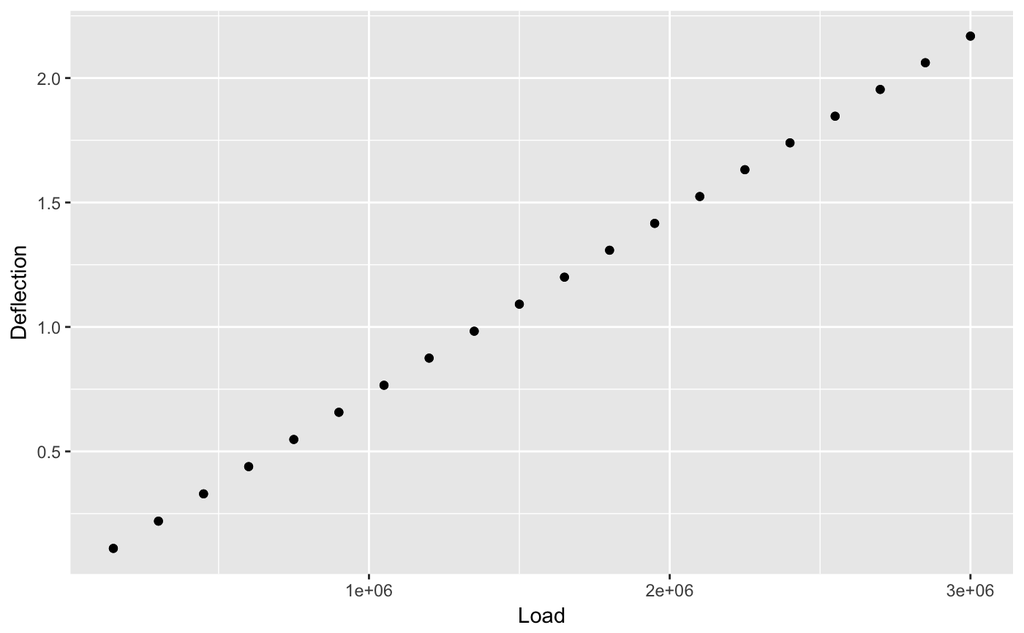

```r
ggplot(load_cell) +
  geom_point(aes(Load, Deflection))
```

The data looks linear. We can use a simple linear model to view the data

$$y = mx + b$$

```r
load_cell_model <- lm(Deflection ~ Load, load_cell)
summary(load_cell_model)
```

```
Call:
lm(formula = Deflection ~ Load, data = load_cell)

Residuals:
       Min         1Q     Median         3Q        Max
-0.0042751 -0.0016308  0.0005818  0.0018932  0.0024211

Coefficients:
             Estimate Std. Error  t value Pr(>|t|)
(Intercept) 6.150e-03  7.132e-04    8.623 1.77e-10 ***
Load        7.221e-07  3.969e-10 1819.289  < 2e-16 ***
---
Signif. codes:  0 ‘***’ 0.001 ‘**’ 0.01 ‘*’ 0.05 ‘.’ 0.1 ‘ ’ 1

Residual standard error: 0.002171 on 38 degrees of freedom
Multiple R-squared:      1, Adjusted R-squared:      1
F-statistic: 3.31e+06 on 1 and 38 DF,  p-value: < 2.2e-16
```

Wow! an R-squared value of 1! it must be perfect.

### A new package to work with summary information: broom()

**broom** package is part of the tidyverse and inccludes `glance()`, `tidy`, and `augment()`. These functions create tidy data frames based on the model.

```r
library(broom)
```

```r
load_cell_glance <- glance(load_cell_model)
load_cell_glance
```

| r.squared | adj.r.squared | sigma | statistic | p.value | df | logLik | AIC | BIC | deviance | df.residual |
| --- | --- | --- | --- | --- | --- | --- | --- | --- | --- | --- |
| 0.9999885 | 0.9999882 | 0.002171273 | 3309811 | 1.773069e-95 | 2 | 189.566 | -373.132 | -368.0654 | 0.0001791481 | 38 |

```r
load_cell_tidy <- tidy(load_cell_model)
load_cell_tidy
```

| term | estimate | std.error | statistic | p.value |
| --- | --- | --- | --- | --- |
| (Intercept) | 6.149684e-03 | 7.132052e-04 | 8.622602 | 1.772153e-10 |
| Load | 7.221026e-07 | 3.969148e-10 | 1819.288717 | 1.773069e-95 |

```r
augment(load_cell_model)
```

| Deflection | Load | .fitted | .se.fit | .resid | .hat | .sigma | .cooksd | .std.resid |
| --- | --- | --- | --- | --- | --- | --- | --- | --- |
| 0.11019 | 150000 | 0.1144651 | 0.0006616404 | -0.0042750714 | 0.09285714 | 0.002073000 | 0.2187217636 | -2.0672413 |
| 0.21956 | 300000 | 0.2227805 | 0.0006115258 | -0.0032204586 | 0.07932331 | 0.002130114 | 0.1029350494 | -1.5457875 |
| 0.32949 | 450000 | 0.3310958 | 0.0005632485 | -0.0016058459 | 0.06729323 | 0.002183373 | 0.0211558343 | -0.7658028 |
| 0.43899 | 600000 | 0.4394112 | 0.0005173233 | -0.0004212331 | 0.05676692 | 0.002199263 | 0.0012007249 | -0.1997554 |
| 0.54803 | 750000 | 0.5477266 | 0.0004744336 | 0.0003033797 | 0.04774436 | 0.002199825 | 0.0005139600 | 0.1431843 |
| 0.65694 | 900000 | 0.6560420 | 0.0004354772 | 0.0008979925 | 0.04022556 | 0.002195253 | 0.0037346550 | 0.4221568 |
| 0.76562 | 1050000 | 0.7643574 | 0.0004016005 | 0.0012626053 | 0.03421053 | 0.002190258 | 0.0062011368 | 0.5917142 |
| 0.87487 | 1200000 | 0.8726728 | 0.0003741856 | 0.0021972180 | 0.02969925 | 0.002169647 | 0.0161517779 | 1.0273197 |
| 0.98292 | 1350000 | 0.9809882 | 0.0003547339 | 0.0019318308 | 0.02669173 | 0.002176743 | 0.0111520670 | 0.9018401 |
| 1.09146 | 1500000 | 1.0893036 | 0.0003445966 | 0.0021564436 | 0.02518797 | 0.002170924 | 0.0130728091 | 1.0059197 |

[output cut: 30 more lines]

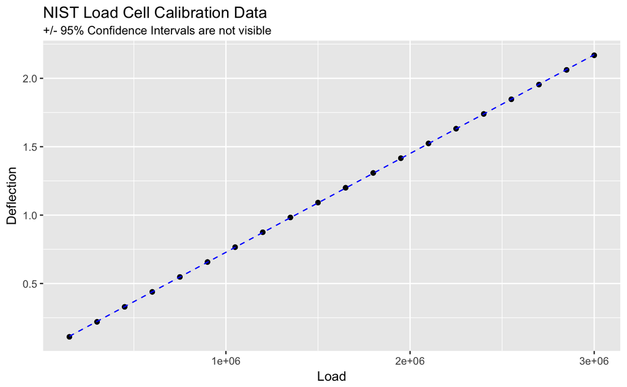

```r
ggplot(load_cell, aes(Load, Deflection)) +
  geom_point() +
  stat_smooth(method = lm, linetype = "dashed", colour = "blue", size = 0.5) +
  ggtitle("NIST Load Cell Calibration Data", subtitle = "+/- 95% Confidence Intervals are not visible")
```

## But wait! What about the residuals?

```r
load_cell_resid = resid(load_cell_model)
load_cell_resid
```

```
            1             2             3             4             5             6             7
-0.0042750714 -0.0032204586 -0.0016058459 -0.0004212331  0.0003033797  0.0008979925  0.0012626053
            8             9            10            11            12            13            14
 0.0021972180  0.0019318308  0.0021564436  0.0023910564  0.0022856692  0.0017402820  0.0014248947
           15            16            17            18            19            20            21
 0.0010595075  0.0002741203 -0.0010512669 -0.0019066541 -0.0028620414 -0.0040174286 -0.0039450714
           22            23            24            25            26            27            28
-0.0026004586 -0.0017058459 -0.0005512331  0.0002533797  0.0013479925  0.0016026053  0.0020672180
           29            30            31            32            33            34            35
 0.0020118308  0.0021964436  0.0024210564  0.0022456692  0.0018802820  0.0015148947  0.0007095075
           36            37            38            39            40
 0.0004541203 -0.0005512669 -0.0013766541 -0.0023720414 -0.0041674286
```

```r
# ggplot() +
#   geom_point(aes(LoadCell$Load, LC.resid)) +
#   geom_hline(aes(yintercept=0)) +
#   geom_hline(aes(yintercept=+2*(summary(m.LC)$sigma)), linetype = "dashed") +
#   geom_hline(aes(yintercept=-2*(summary(m.LC)$sigma)), linetype = "dashed") +
#   ggtitle("Deflection Load Residuals", subtitle = "+/- 2(Residual Statndard Deviation)") +
#   theme(plot.title = element_text(hjust = 0.5), plot.subtitle = element_text(hjust = 0.5))
```

Using the `augment()` function we can plot the residuals very easily

```r
load_cell_fit <- augment(load_cell_model)
load_cell_fit
```

| Deflection | Load | .fitted | .se.fit | .resid | .hat | .sigma | .cooksd | .std.resid |
| --- | --- | --- | --- | --- | --- | --- | --- | --- |
| 0.11019 | 150000 | 0.1144651 | 0.0006616404 | -0.0042750714 | 0.09285714 | 0.002073000 | 0.2187217636 | -2.0672413 |
| 0.21956 | 300000 | 0.2227805 | 0.0006115258 | -0.0032204586 | 0.07932331 | 0.002130114 | 0.1029350494 | -1.5457875 |
| 0.32949 | 450000 | 0.3310958 | 0.0005632485 | -0.0016058459 | 0.06729323 | 0.002183373 | 0.0211558343 | -0.7658028 |
| 0.43899 | 600000 | 0.4394112 | 0.0005173233 | -0.0004212331 | 0.05676692 | 0.002199263 | 0.0012007249 | -0.1997554 |
| 0.54803 | 750000 | 0.5477266 | 0.0004744336 | 0.0003033797 | 0.04774436 | 0.002199825 | 0.0005139600 | 0.1431843 |
| 0.65694 | 900000 | 0.6560420 | 0.0004354772 | 0.0008979925 | 0.04022556 | 0.002195253 | 0.0037346550 | 0.4221568 |
| 0.76562 | 1050000 | 0.7643574 | 0.0004016005 | 0.0012626053 | 0.03421053 | 0.002190258 | 0.0062011368 | 0.5917142 |
| 0.87487 | 1200000 | 0.8726728 | 0.0003741856 | 0.0021972180 | 0.02969925 | 0.002169647 | 0.0161517779 | 1.0273197 |
| 0.98292 | 1350000 | 0.9809882 | 0.0003547339 | 0.0019318308 | 0.02669173 | 0.002176743 | 0.0111520670 | 0.9018401 |
| 1.09146 | 1500000 | 1.0893036 | 0.0003445966 | 0.0021564436 | 0.02518797 | 0.002170924 | 0.0130728091 | 1.0059197 |

[output cut: 30 more lines]

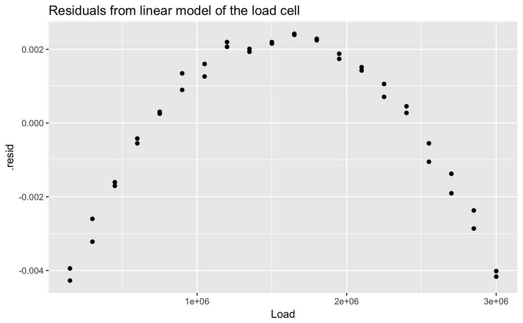

```r
ggplot(load_cell_fit) +
  geom_point(aes(Load, .resid)) +
  ggtitle("Residuals from linear model of the load cell")
```

The residuals from a good model would be random. Although not necessary, we can plot a histogram or qqplot to demonstrate the residuals are not following a normal distribution.

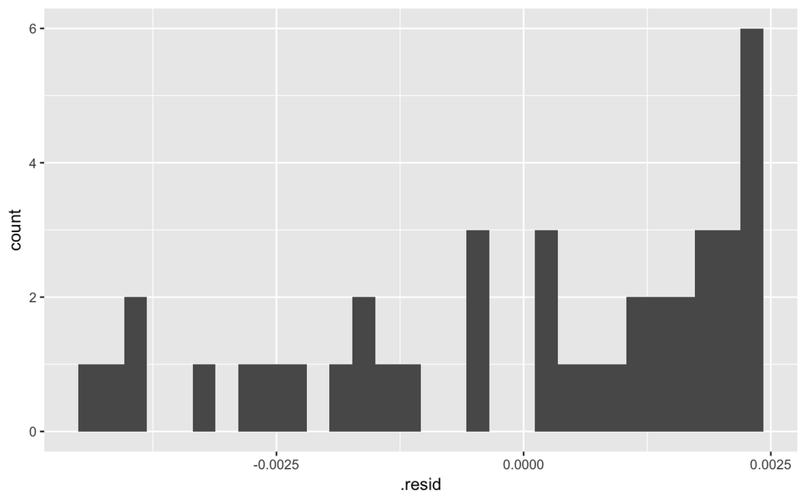

```r
ggplot(load_cell_fit) +
  geom_histogram(aes(.resid))
```

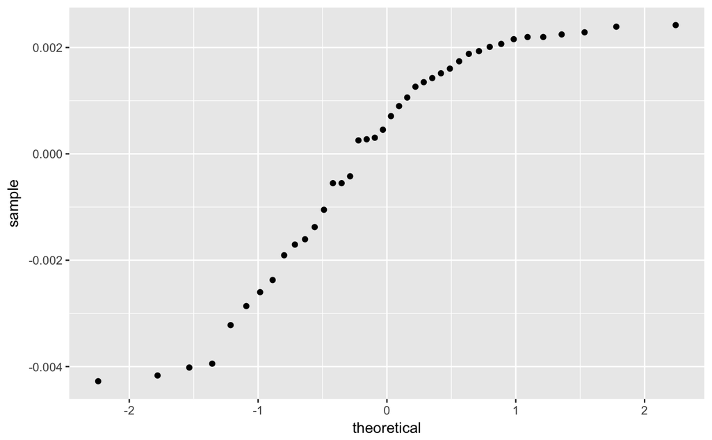

```r
ggplot(load_cell_fit) +
  geom_qq(aes(sample = .resid))
```

## Model Refinement

$$D = \beta_0 + \beta_1 L + \beta_2 L^2 + \varepsilon$$

We can use the linear model function, `lm()`, by creating a new variable $L^2$.

```r
load_cell_2 <- mutate(load_cell, Load_squared = Load^2)
load_cell_2
```

| Deflection | Load | Load_squared |
| --- | --- | --- |
| 0.11019 | 150000 | 2.2500e+10 |
| 0.21956 | 300000 | 9.0000e+10 |
| 0.32949 | 450000 | 2.0250e+11 |
| 0.43899 | 600000 | 3.6000e+11 |
| 0.54803 | 750000 | 5.6250e+11 |
| 0.65694 | 900000 | 8.1000e+11 |
| 0.76562 | 1050000 | 1.1025e+12 |
| 0.87487 | 1200000 | 1.4400e+12 |
| 0.98292 | 1350000 | 1.8225e+12 |
| 1.09146 | 1500000 | 2.2500e+12 |

[output cut: 30 more lines]

```r
load_cell_model_2 <- lm(Deflection ~ Load + Load_squared, load_cell_2)
summary(load_cell_model_2)
```

```
Call:
lm(formula = Deflection ~ Load + Load_squared, data = load_cell_2)

Residuals:
       Min         1Q     Median         3Q        Max
-4.468e-04 -1.578e-04  3.817e-05  1.088e-04  4.235e-04

Coefficients:
               Estimate Std. Error t value Pr(>|t|)
(Intercept)   6.736e-04  1.079e-04    6.24 2.97e-07 ***
Load          7.321e-07  1.578e-10 4638.65  < 2e-16 ***
Load_squared -3.161e-15  4.867e-17  -64.95  < 2e-16 ***
---
Signif. codes:  0 ‘***’ 0.001 ‘**’ 0.01 ‘*’ 0.05 ‘.’ 0.1 ‘ ’ 1

Residual standard error: 0.0002052 on 37 degrees of freedom
Multiple R-squared:      1, Adjusted R-squared:      1
F-statistic: 1.853e+08 on 2 and 37 DF,  p-value: < 2.2e-16
```

```r
load_cell_fit_2 <- augment(load_cell_model_2)
load_cell_fit_2
```

| Deflection | Load | Load_squared | .fitted | .se.fit | .resid | .hat | .sigma | .cooksd | .std.resid |
| --- | --- | --- | --- | --- | --- | --- | --- | --- | --- |
| 0.11019 | 150000 | 2.2500e+10 | 0.1104113 | 8.834303e-05 | -2.213214e-04 | 0.18538961 | 0.0002039531 | 0.1083557670 | -1.1951404 |
| 0.21956 | 300000 | 9.0000e+10 | 0.2200068 | 7.185366e-05 | -4.468402e-04 | 0.12264183 | 0.0001922123 | 0.2518888277 | -2.3250603 |
| 0.32949 | 450000 | 2.0250e+11 | 0.3294601 | 5.888246e-05 | 2.987782e-05 | 0.08235931 | 0.0002079426 | 0.0006913290 | 0.1520138 |
| 0.43899 | 600000 | 3.6000e+11 | 0.4387712 | 4.986859e-05 | 2.188327e-04 | 0.05907382 | 0.0002045811 | 0.0253004370 | 1.0995244 |
| 0.54803 | 750000 | 5.6250e+11 | 0.5479400 | 4.495244e-05 | 9.002444e-05 | 0.04800068 | 0.0002074384 | 0.0033987136 | 0.4496893 |
| 0.65694 | 900000 | 8.1000e+11 | 0.6569665 | 4.354343e-05 | -2.654699e-05 | 0.04503873 | 0.0002079583 | 0.0002755909 | -0.1324015 |
| 0.76562 | 1050000 | 1.1025e+12 | 0.7658509 | 4.437259e-05 | -2.308816e-04 | 0.04677033 | 0.0002042395 | 0.0217256885 | -1.1525531 |
| 0.87487 | 1200000 | 1.4400e+12 | 0.8745930 | 4.609026e-05 | 2.770207e-04 | 0.05046138 | 0.0002025394 | 0.0340077449 | 1.3855631 |
| 0.98292 | 1350000 | 1.8225e+12 | 0.9831928 | 4.770597e-05 | -2.728402e-04 | 0.05406129 | 0.0002026849 | 0.0356120360 | -1.3672481 |
| 1.09146 | 1500000 | 2.2500e+12 | 1.0916505 | 4.864177e-05 | -1.904643e-04 | 0.05620301 | 0.0002054251 | 0.0181237925 | -0.9555308 |

[output cut: 30 more lines]

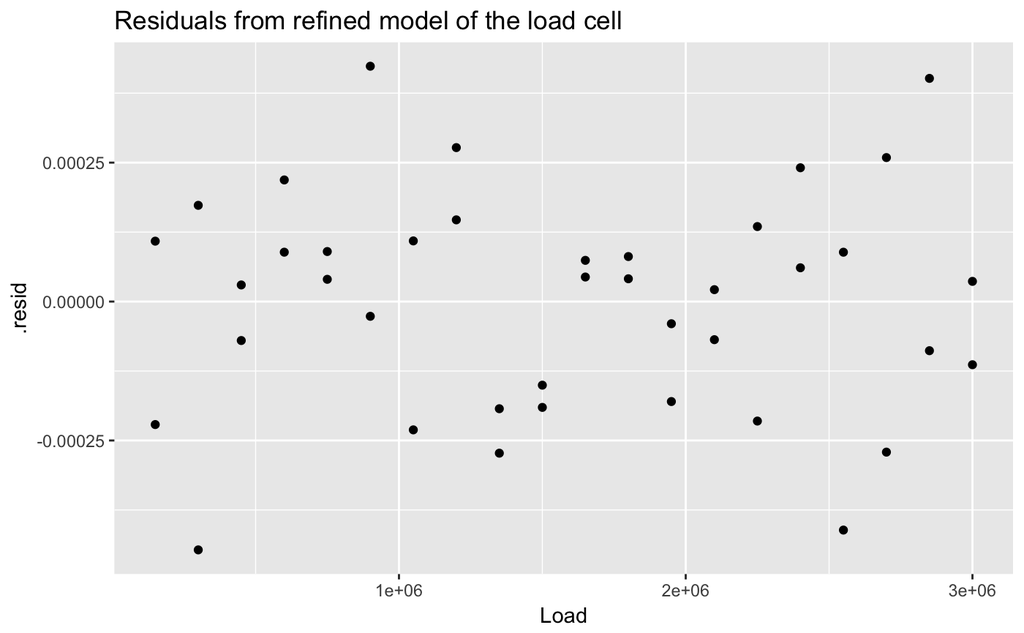

```r
ggplot(load_cell_fit_2) +
  geom_point(aes(Load, .resid)) +
  ggtitle("Residuals from refined model of the load cell")
```

### Could we have used a non-linear least squares fit model?

```r
load_cell_model_3 <- nls(Deflection ~ b0 + b1*Load + b2*Load^2, load_cell_2, start = c(b0 = 0, b1 = 0,b2 = 0))
summary(load_cell_model_3)
```

```
Formula: Deflection ~ b0 + b1 * Load + b2 * Load^2

Parameters:
     Estimate Std. Error t value Pr(>|t|)
b0  6.736e-04  1.079e-04    6.24 2.97e-07 ***
b1  7.321e-07  1.578e-10 4638.65  < 2e-16 ***
b2 -3.161e-15  4.867e-17  -64.95  < 2e-16 ***
---
Signif. codes:  0 ‘***’ 0.001 ‘**’ 0.01 ‘*’ 0.05 ‘.’ 0.1 ‘ ’ 1

Residual standard error: 0.0002052 on 37 degrees of freedom

Number of iterations to convergence: 1
Achieved convergence tolerance: 1.328e-06
```

The results are identical.

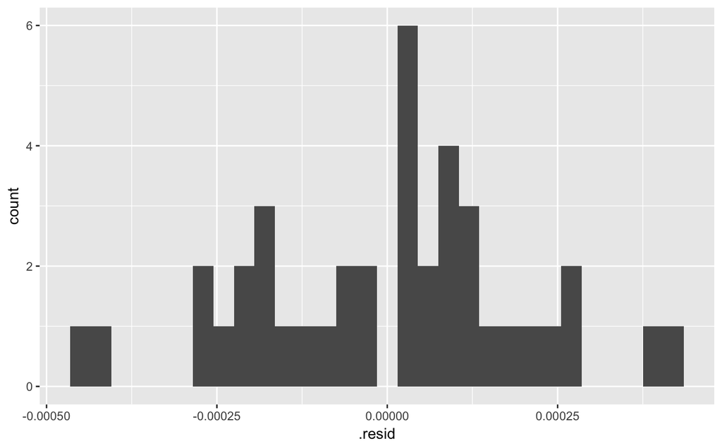

```r
ggplot(load_cell_fit_2) +
  geom_histogram(aes(.resid))
```

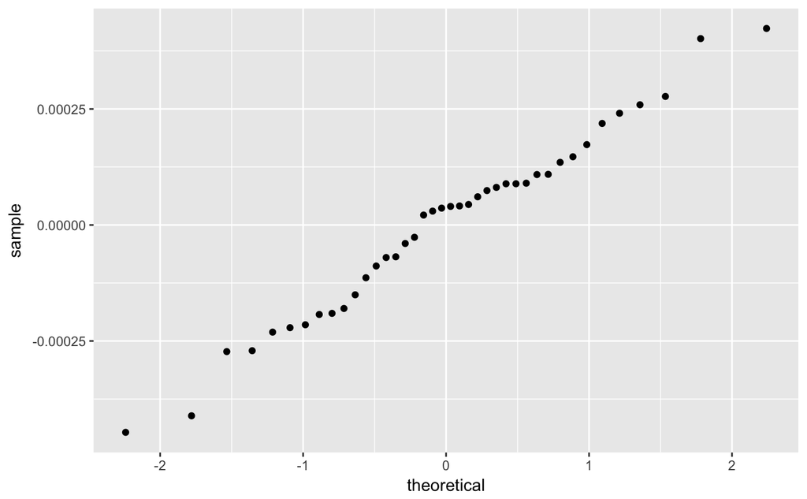

```r
ggplot(load_cell_fit_2) +
  geom_qq(aes(sample = .resid))
```

## Progaming with `case_when()`

Looking at the orginal data set, we can see that there are two sets of data. We might want to label these as “run1” and “run2.” we could do this in Excel using an `IF()` function. In the **tidyverse**, we can use the `case_when()` function.

```r
load_cell_fit_2
```

| Deflection | Load | Load_squared | .fitted | .se.fit | .resid | .hat | .sigma | .cooksd | .std.resid |
| --- | --- | --- | --- | --- | --- | --- | --- | --- | --- |
| 0.11019 | 150000 | 2.2500e+10 | 0.1104113 | 8.834303e-05 | -2.213214e-04 | 0.18538961 | 0.0002039531 | 0.1083557670 | -1.1951404 |
| 0.21956 | 300000 | 9.0000e+10 | 0.2200068 | 7.185366e-05 | -4.468402e-04 | 0.12264183 | 0.0001922123 | 0.2518888277 | -2.3250603 |
| 0.32949 | 450000 | 2.0250e+11 | 0.3294601 | 5.888246e-05 | 2.987782e-05 | 0.08235931 | 0.0002079426 | 0.0006913290 | 0.1520138 |
| 0.43899 | 600000 | 3.6000e+11 | 0.4387712 | 4.986859e-05 | 2.188327e-04 | 0.05907382 | 0.0002045811 | 0.0253004370 | 1.0995244 |
| 0.54803 | 750000 | 5.6250e+11 | 0.5479400 | 4.495244e-05 | 9.002444e-05 | 0.04800068 | 0.0002074384 | 0.0033987136 | 0.4496893 |
| 0.65694 | 900000 | 8.1000e+11 | 0.6569665 | 4.354343e-05 | -2.654699e-05 | 0.04503873 | 0.0002079583 | 0.0002755909 | -0.1324015 |
| 0.76562 | 1050000 | 1.1025e+12 | 0.7658509 | 4.437259e-05 | -2.308816e-04 | 0.04677033 | 0.0002042395 | 0.0217256885 | -1.1525531 |
| 0.87487 | 1200000 | 1.4400e+12 | 0.8745930 | 4.609026e-05 | 2.770207e-04 | 0.05046138 | 0.0002025394 | 0.0340077449 | 1.3855631 |
| 0.98292 | 1350000 | 1.8225e+12 | 0.9831928 | 4.770597e-05 | -2.728402e-04 | 0.05406129 | 0.0002026849 | 0.0356120360 | -1.3672481 |
| 1.09146 | 1500000 | 2.2500e+12 | 1.0916505 | 4.864177e-05 | -1.904643e-04 | 0.05620301 | 0.0002054251 | 0.0181237925 | -0.9555308 |

[output cut: 30 more lines]

```r
load_cell_fit_2_runs <- load_cell_fit_2 %>%
  mutate(
    run = case_when(seq_along(Load) <= 20 ~ "run1",
                    seq_along(Load) > 20 ~ "run2"))
load_cell_fit_2_runs
```

| Deflection | Load | Load_squared | .fitted | .se.fit | .resid | .hat | .sigma | .cooksd | .std.resid | run |
| --- | --- | --- | --- | --- | --- | --- | --- | --- | --- | --- |
| 0.11019 | 150000 | 2.2500e+10 | 0.1104113 | 8.834303e-05 | -2.213214e-04 | 0.18538961 | 0.0002039531 | 0.1083557670 | -1.1951404 | run1 |
| 0.21956 | 300000 | 9.0000e+10 | 0.2200068 | 7.185366e-05 | -4.468402e-04 | 0.12264183 | 0.0001922123 | 0.2518888277 | -2.3250603 | run1 |
| 0.32949 | 450000 | 2.0250e+11 | 0.3294601 | 5.888246e-05 | 2.987782e-05 | 0.08235931 | 0.0002079426 | 0.0006913290 | 0.1520138 | run1 |
| 0.43899 | 600000 | 3.6000e+11 | 0.4387712 | 4.986859e-05 | 2.188327e-04 | 0.05907382 | 0.0002045811 | 0.0253004370 | 1.0995244 | run1 |
| 0.54803 | 750000 | 5.6250e+11 | 0.5479400 | 4.495244e-05 | 9.002444e-05 | 0.04800068 | 0.0002074384 | 0.0033987136 | 0.4496893 | run1 |
| 0.65694 | 900000 | 8.1000e+11 | 0.6569665 | 4.354343e-05 | -2.654699e-05 | 0.04503873 | 0.0002079583 | 0.0002755909 | -0.1324015 | run1 |
| 0.76562 | 1050000 | 1.1025e+12 | 0.7658509 | 4.437259e-05 | -2.308816e-04 | 0.04677033 | 0.0002042395 | 0.0217256885 | -1.1525531 | run1 |
| 0.87487 | 1200000 | 1.4400e+12 | 0.8745930 | 4.609026e-05 | 2.770207e-04 | 0.05046138 | 0.0002025394 | 0.0340077449 | 1.3855631 | run1 |
| 0.98292 | 1350000 | 1.8225e+12 | 0.9831928 | 4.770597e-05 | -2.728402e-04 | 0.05406129 | 0.0002026849 | 0.0356120360 | -1.3672481 | run1 |
| 1.09146 | 1500000 | 2.2500e+12 | 1.0916505 | 4.864177e-05 | -1.904643e-04 | 0.05620301 | 0.0002054251 | 0.0181237925 | -0.9555308 | run1 |

[output cut: 30 more lines]

# EDA of load cell data by run

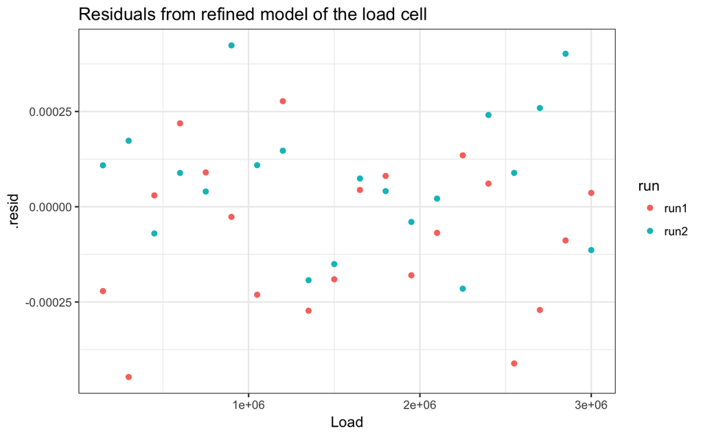

```r
ggplot(load_cell_fit_2_runs) +
  geom_point(aes(Load, .resid, colour = run)) +
  ggtitle("Residuals from refined model of the load cell") +
  theme_bw()
```

# NIST Case Study - Thermal Expansion

> This case study illustrates the use of a class of nonlinear models called rational function models. The data set used is the thermal expansion of copper related to temperature.

> The response variable for this data set is the coefficient of thermal expansion for copper. The predictor variable is temperature in degrees kelvin. There were 236 data points collected.

```r
CTECu <- read_table2(
  "Coefficient of Thermal Expansion - Cu.txt")
CTECu
```

| Cu | Temp |
| --- | --- |
| 0.591 | 24.41 |
| 1.547 | 34.82 |
| 2.902 | 44.09 |
| 2.894 | 45.07 |
| 4.703 | 54.98 |
| 6.307 | 65.51 |
| 7.030 | 70.53 |
| 7.898 | 75.70 |
| 9.470 | 89.57 |
| 9.484 | 91.14 |

[output cut: 226 more lines]

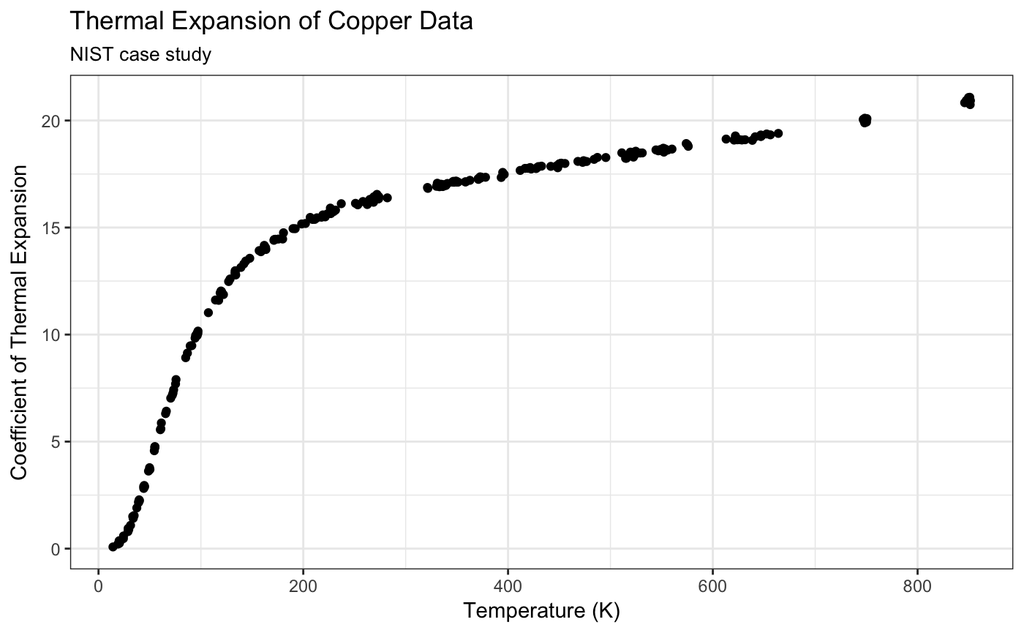

```r
ggplot(CTECu) +
  geom_point(aes(Temp, Cu)) +
  ggtitle("Thermal Expansion of Copper Data", subtitle = "NIST case study") +
  labs(x = "Temperature (K)", y = "Coefficient of Thermal Expansion") +
  theme_bw()
```

## Quadratic/Quadratic Rational Function Model

```r
Cu_model <- nls(Cu ~ ((a0 + a1*Temp + a2*Temp^2)/(1 + b1*Temp + b2*Temp^2)),
            CTECu, start = list(a0 = 0, a1 = -1, a2 = -1, b1 = 0, b2 = 0), trace = T)
```

```
1.344556e+13 :   0 -1 -1  0  0
1697329 :  -3.351400e+00  1.797879e-01 -5.745645e-04  7.915158e-07 -3.877688e-10
177589.3 :  -3.319661e+00  1.750319e-01 -3.592189e-04  1.144561e-03 -6.445222e-07
32411.82 :  -4.730736e+00  2.146213e-01 -3.235814e-04  3.851759e-03 -2.232626e-06
5374.946 :  -6.413603e+00  2.683958e-01 -2.844465e-04  7.799104e-03 -4.266107e-06
690.5713 :  -6.901674e+00  2.867489e-01 -1.804611e-04  1.009256e-02 -3.131612e-06
217.1164 :  -5.970973e+00  2.481232e-01  1.250216e-04  8.918691e-03  1.150181e-05
114.0929 :  -3.145220e+00  1.061122e-01  1.610442e-03  4.783451e-03  8.707152e-05
64.59622 :   3.1477349163 -0.2965983768  0.0078946767  0.0013004690  0.0003974542
42.78158 :   9.3230025114 -0.8210512798  0.0188009501  0.0103976361  0.0009147904
34.34313 :  11.848742450 -1.098105431  0.025888747  0.024139632  0.001231568
33.5614 :  11.838847499 -1.129134608  0.027249383  0.029538247  0.001286009
33.55298 :  12.220405792 -1.169396827  0.028259353  0.031296606  0.001332281
33.55278 :  11.988150281 -1.149285630  0.027831681  0.030880324  0.001312172
33.55273 :  12.165006923 -1.165285413  0.028186412  0.031296535  0.001328754
33.55271 :  12.034452089 -1.153533233  0.027926998  0.030997296  0.001316621
33.55269 :  12.131480095 -1.162274660  0.028120094  0.031220657  0.001325652
33.55268 :  12.059618930 -1.155801947  0.027977138  0.031055397  0.001318966
33.55268 :  12.112946981 -1.160605895  0.028083247  0.031178098  0.001323928
33.55268 :  12.073406215 -1.157044238  0.028004583  0.031087151  0.001320249
33.55267 :  12.102793316 -1.159691514  0.028063056  0.031154770  0.001322984
33.55267 :  12.081046435 -1.157732650  0.028019791  0.031104752  0.001320961
33.55267 :  12.097167203 -1.159184809  0.028051866  0.031141839  0.001322461
33.55267 :  12.085177311 -1.158104731  0.028028009  0.031114250  0.001321345
33.55267 :  12.094068505 -1.158905649  0.028045699  0.031134704  0.001322172
33.55267 :  12.087436601 -1.158308224  0.028032503  0.031119442  0.001321555
33.55267 :  12.092386536 -1.158754113  0.028042351  0.031130832  0.001322016
33.55267 :  12.088732963 -1.158425030  0.028035083  0.031122431  0.001321676
33.55267 :  12.091445289 -1.158669369  0.028040481  0.031128672  0.001321928
33.55267 :  12.08942043 -1.15848695  0.02803645  0.03112401  0.00132174
33.55267 :  12.090900623 -1.158620261  0.028039395  0.031127413  0.001321877
33.55267 :  12.089833503 -1.158524186  0.028037274  0.031124964  0.001321778
33.55267 :  12.090620445 -1.158595059  0.028038839  0.031126773  0.001321851
```

```r
augment(Cu_model)
```

| Cu | Temp | .fitted | .resid |
| --- | --- | --- | --- |
| 0.591 | 24.41 | 0.20263740 | 0.388362604 |
| 1.547 | 34.82 | 1.55799629 | -0.010996290 |
| 2.902 | 44.09 | 3.13916746 | -0.237167465 |
| 2.894 | 45.07 | 3.30744524 | -0.413445244 |
| 4.703 | 54.98 | 4.94210005 | -0.239100048 |
| 6.307 | 65.51 | 6.48782610 | -0.180826097 |
| 7.030 | 70.53 | 7.14914778 | -0.119147778 |
| 7.898 | 75.70 | 7.78154503 | 0.116454973 |
| 9.470 | 89.57 | 9.25903236 | 0.210967637 |
| 9.484 | 91.14 | 9.40826472 | 0.075735280 |

[output cut: 226 more lines]

```r
summary(Cu_model)
```

```
Formula: Cu ~ ((a0 + a1 * Temp + a2 * Temp^2)/(1 + b1 * Temp + b2 * Temp^2))

Parameters:
     Estimate Std. Error t value Pr(>|t|)
a0 12.0906204  4.9457268   2.445  0.01525 *
a1 -1.1585951  0.4459281  -2.598  0.00997 **
a2  0.0280388  0.0099339   2.823  0.00518 **
b1  0.0311268  0.0123461   2.521  0.01237 *
b2  0.0013219  0.0004639   2.849  0.00478 **
---
Signif. codes:  0 ‘***’ 0.001 ‘**’ 0.01 ‘*’ 0.05 ‘.’ 0.1 ‘ ’ 1

Residual standard error: 0.3811 on 231 degrees of freedom

Number of iterations to convergence: 32
Achieved convergence tolerance: 8.018e-06
```

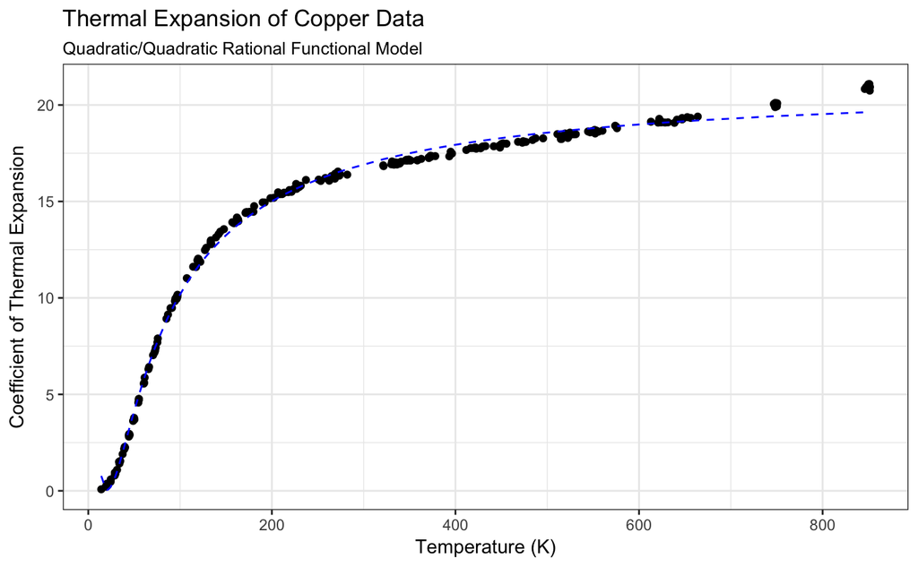

```r
Cu_model %>%
  augment() %>%
  ggplot() +
  geom_point(aes(Temp, Cu)) +
  geom_line(aes(Temp, .fitted), colour = "blue", linetype = "dashed") +
  ggtitle("Thermal Expansion of Copper Data", subtitle = "Quadratic/Quadratic Rational Functional Model") +
  labs(x = "Temperature (K)", y = "Coefficient of Thermal Expansion") +
  theme_bw()
```

```r
NA
```

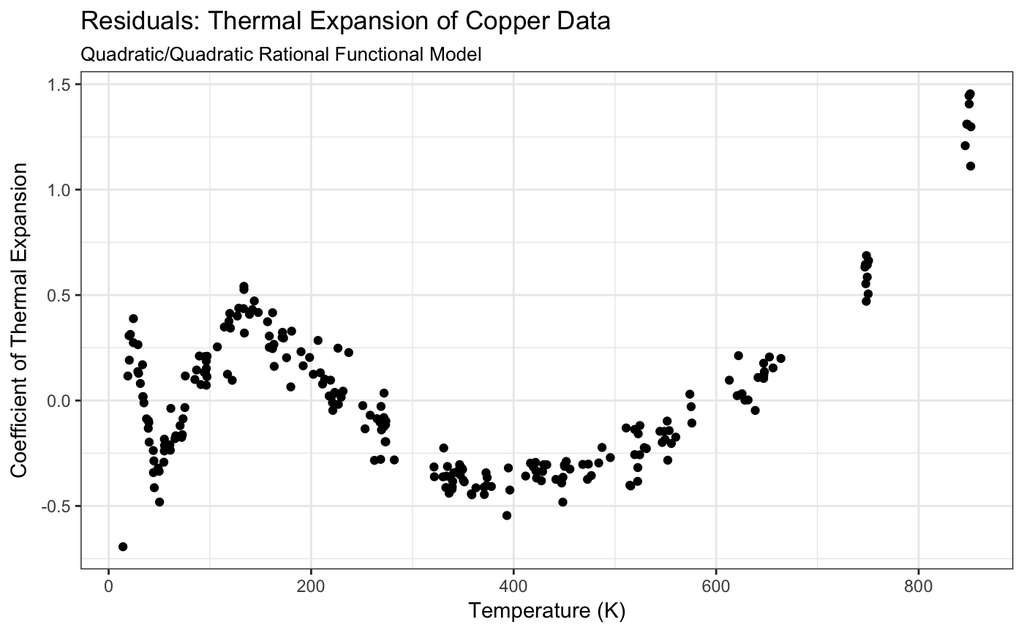

```r
Cu_model %>%
  augment() %>%
  ggplot() +
  geom_point(aes(Temp, .resid))+
  ggtitle("Residuals: Thermal Expansion of Copper Data", subtitle = "Quadratic/Quadratic Rational Functional Model") +
  labs(x = "Temperature (K)", y = "Coefficient of Thermal Expansion") +
  theme_bw()
```

> The full-sized residual plot clearly shows the distinct pattern in the residuals. When residuals exhibit a clear pattern, the corresponding errors are probably not random.

```r
Cu_model_cc <- nls(Cu ~ ((a0 + a1*Temp + a2*Temp^2 + a3*Temp^3)/(1 + b1*Temp + b2*Temp^2 + b3*Temp^3)),
            CTECu, start = list(a0 = 0, a1 = -1, a2 = -1, a3 = 0, b1 = 0, b2 = 0, b3 = 0),
            trace = T)
```

```
1.344556e+13 :   0 -1 -1  0  0  0  0
1.339595e+13 :  -4.089856e-03 -9.988271e-01 -9.983564e-01  6.676610e-04 -6.676602e-04 -1.055201e-11  1.803518e-15
1.334366e+13 :  -4.807459e-03 -9.966232e-01 -9.964072e-01  6.664584e-04 -6.677607e-04 -1.094787e-11  1.584238e-15
1.32396e+13 :  -6.863478e-03 -9.922082e-01 -9.925166e-01  6.639777e-04 -6.678813e-04 -1.223912e-11  1.510447e-15
1.30334e+13 :  -1.594000e-02 -9.833127e-01 -9.847661e-01  6.593020e-04 -6.683904e-04 -1.602231e-11  1.289942e-15
1.262831e+13 :  -6.540076e-02 -9.650849e-01 -9.693885e-01  6.507887e-04 -6.701861e-04 -3.033631e-11  1.802077e-15
1.184743e+13 :  -1.788916e-01 -9.289031e-01 -9.391153e-01  6.341455e-04 -6.739522e-04 -6.184747e-11  2.875150e-15
1.040295e+13 :  -4.142861e-01 -8.583930e-01 -8.804668e-01  5.994049e-04 -6.790616e-04 -1.428677e-10  1.605646e-14
7.989692e+12 :  -9.341122e-01 -7.234575e-01 -7.705432e-01  5.175015e-04 -6.708211e-04 -4.851866e-10  1.813912e-13
6.371193e+12 :  -1.922326e+00 -4.855256e-01 -5.789681e-01 -4.405781e-04  4.048477e-04 -1.132038e-09  4.421753e-13
1.590227e+12 :  -3.385858e+00 -1.294959e-01 -2.899297e-01 -2.187966e-04  4.037949e-04 -2.100189e-09  8.979057e-13
19889209 :  -4.850624e+00  2.266128e-01 -8.927502e-04  3.128700e-06  3.991144e-04 -5.877643e-09  2.695245e-12
825292.5 :  -4.854099e+00  2.244501e-01 -7.872443e-04  1.327192e-06  8.773391e-04  4.504172e-08 -1.183450e-10
72834.96 :  -4.698904e+00  2.158071e-01 -6.255161e-04  8.206990e-07  1.206312e-03  1.711327e-06 -1.281084e-09
11897.69 :  -4.260919e+00  1.962288e-01 -4.518142e-04  6.174559e-07  5.394675e-04  9.144746e-06 -6.252643e-09
3068.102 :  -3.363680e+00  1.545785e-01 -1.051538e-04  4.250646e-07 -1.433242e-03  2.984461e-05 -2.070801e-08
909.5887 :  -1.947093e+00  8.097392e-02  6.980495e-04 -2.856405e-08 -4.239912e-03  7.556907e-05 -5.390319e-08
220.8618 :  -4.057550e-01 -1.376339e-02  2.096694e-03 -9.279485e-07 -6.080614e-03  1.470438e-04 -1.056115e-07
31.88262 :   7.090768e-01 -9.381732e-02  3.536101e-03 -1.838264e-06 -6.162496e-03  2.145881e-04 -1.480838e-07
3.200182 :   1.102048e+00 -1.249213e-01  4.149347e-03 -1.951524e-06 -5.756966e-03  2.422411e-04 -1.492413e-07
1.55733 :   1.100520e+00 -1.246480e-01  4.131519e-03 -1.571143e-06 -5.729023e-03  2.422069e-04 -1.300201e-07
1.532465 :   1.080053e+00 -1.228904e-01  4.090638e-03 -1.435504e-06 -5.758189e-03  2.407076e-04 -1.235758e-07
1.532438 :   1.077745e+00 -1.227015e-01  4.086549e-03 -1.426532e-06 -5.760914e-03  2.405448e-04 -1.231569e-07
1.532438 :   1.077639e+00 -1.226932e-01  4.086381e-03 -1.426274e-06 -5.760992e-03  2.405376e-04 -1.231449e-07
```

```r
augment(Cu_model_cc)
```

| Cu | Temp | .fitted | .resid |
| --- | --- | --- | --- |
| 0.591 | 24.41 | 0.4963639 | 0.094636113 |
| 1.547 | 34.82 | 1.5653400 | -0.018340010 |
| 2.902 | 44.09 | 2.9005739 | 0.001426132 |
| 2.894 | 45.07 | 3.0533083 | -0.159308281 |
| 4.703 | 54.98 | 4.6386624 | 0.064337570 |
| 6.307 | 65.51 | 6.2804623 | 0.026537706 |
| 7.030 | 70.53 | 7.0126772 | 0.017322841 |
| 7.898 | 75.70 | 7.7231356 | 0.174864443 |
| 9.470 | 89.57 | 9.3955397 | 0.074460287 |
| 9.484 | 91.14 | 9.5636985 | -0.079698527 |

[output cut: 226 more lines]

```r
summary(Cu_model_cc)
```

```
Formula: Cu ~ ((a0 + a1 * Temp + a2 * Temp^2 + a3 * Temp^3)/(1 + b1 *
    Temp + b2 * Temp^2 + b3 * Temp^3))

Parameters:
     Estimate Std. Error t value Pr(>|t|)
a0  1.078e+00  1.707e-01   6.313 1.40e-09 ***
a1 -1.227e-01  1.200e-02 -10.224  < 2e-16 ***
a2  4.086e-03  2.251e-04  18.155  < 2e-16 ***
a3 -1.426e-06  2.758e-07  -5.172 5.06e-07 ***
b1 -5.761e-03  2.471e-04 -23.312  < 2e-16 ***
b2  2.405e-04  1.045e-05  23.019  < 2e-16 ***
b3 -1.231e-07  1.303e-08  -9.453  < 2e-16 ***
---
Signif. codes:  0 ‘***’ 0.001 ‘**’ 0.01 ‘*’ 0.05 ‘.’ 0.1 ‘ ’ 1

Residual standard error: 0.0818 on 229 degrees of freedom

Number of iterations to convergence: 23
Achieved convergence tolerance: 1.664e-06
```

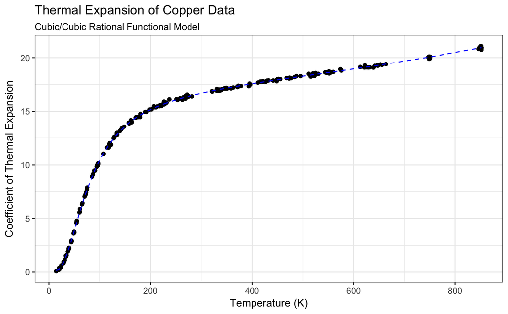

```r
Cu_model_cc %>%
  augment() %>%
  ggplot() +
  geom_point(aes(Temp, Cu)) +
  geom_line(aes(Temp, .fitted), colour = "blue", linetype = "dashed") +
  ggtitle("Thermal Expansion of Copper Data", subtitle = "Cubic/Cubic Rational Functional Model") +
  labs(x = "Temperature (K)", y = "Coefficient of Thermal Expansion") +
  theme_bw()
```

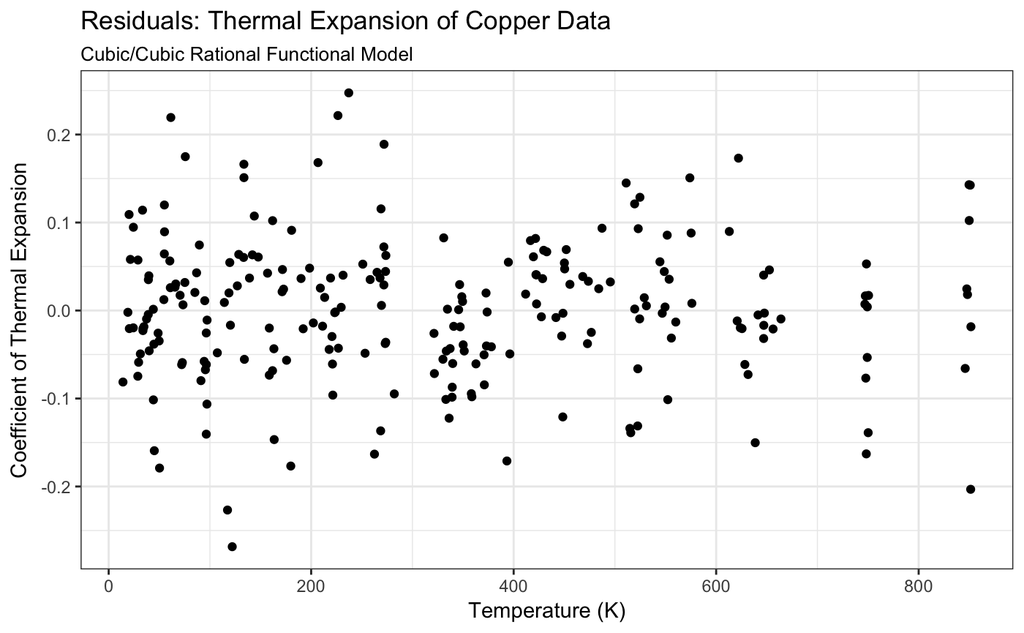

```r
Cu_model_cc %>%
  augment() %>%
  ggplot() +
  geom_point(aes(Temp, .resid))+
  ggtitle("Residuals: Thermal Expansion of Copper Data", subtitle = "Cubic/Cubic Rational Functional Model") +
  labs(x = "Temperature (K)", y = "Coefficient of Thermal Expansion") +
  theme_bw()
```

Residuals are random.

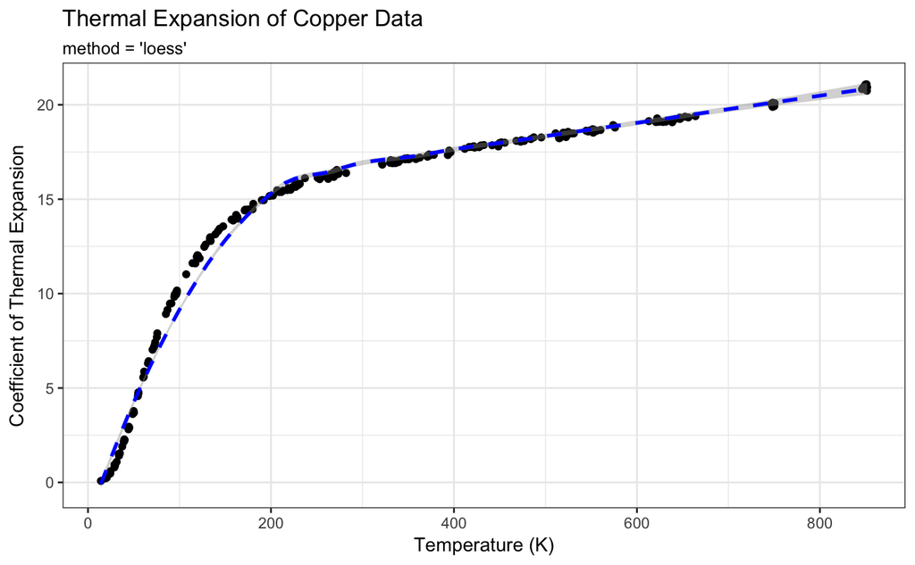

```r
Cu_model_cc %>%
  augment() %>%
  ggplot() +
  geom_point(aes(Temp, Cu)) +
  geom_smooth(aes(Temp, Cu), method = "loess", colour = "blue", linetype = "dashed") +
  ggtitle("Thermal Expansion of Copper Data", subtitle = "method = 'loess'") +
  labs(x = "Temperature (K)", y = "Coefficient of Thermal Expansion") +
  theme_bw()
```